# NikhilShankarChirakkalSivasankaran_9026254_2_Final_Part_B

### **Final Exam Part-B**

#### **CSCN8000-Artificial Intelligence Algorithms and Mathematics**

##### **Nikhil Shankar Chirakkal Sivasankaran** - 9026254

#### **Data Analysis & EDA**

##### **Train & Test Splits**

```python
dataset_train_path = "../dataset/fashionmnist-datafiles/x_train.csv"
dataset_test_path = "../dataset/fashionmnist-datafiles/x_test.csv"
dataset_label_train_path = "../dataset/fashionmnist-datafiles/y_train.csv"
dataset_label_test_path = "../dataset/fashionmnist-datafiles/y_test.csv"
```

```python
import pandas as pd
import numpy as np



print("*"*50)
print("TRAIN DATASET")
train_df = pd.read_csv(dataset_train_path)
display(train_df.head(5))
display(len(train_df))
print("*"*50)
print("UNIQUE TRAIN LABELS")
label_train_df = pd.read_csv(dataset_label_train_path)
display(label_train_df.iloc[:, 0].unique())
display(len(label_train_df))

print("*"*50)
print("TEST DATASET")
test_df = pd.read_csv(dataset_test_path)
display(test_df.head(5))
display(len(test_df))
print("*"*50)
print("UNIQUE TEST LABELS")
label_test_df = pd.read_csv(dataset_label_test_path)
display(label_test_df.iloc[:, 0].unique())
display(len(label_test_df))
```

```
TRAIN DATASET
```

|  | 0 | 1 | 2 | 3 | 4 | 5 | 6 | 7 | 8 | 9 | ... | 774 | 775 | 776 | 777 | 778 | 779 | 780 | 781 | 782 | 783 |
| --- | --- | --- | --- | --- | --- | --- | --- | --- | --- | --- | --- | --- | --- | --- | --- | --- | --- | --- | --- | --- | --- |
| 0 | 0 | 0 | 0 | 0 | 0 | 0 | 0 | 0 | 0 | 0 | ... | 0 | 0 | 0 | 0 | 0 | 0 | 0 | 0 | 0 | 0 |
| 1 | 0 | 0 | 0 | 0 | 0 | 1 | 0 | 0 | 0 | 0 | ... | 119 | 114 | 130 | 76 | 0 | 0 | 0 | 0 | 0 | 0 |
| 2 | 0 | 0 | 0 | 0 | 0 | 0 | 0 | 0 | 0 | 22 | ... | 0 | 0 | 1 | 0 | 0 | 0 | 0 | 0 | 0 | 0 |
| 3 | 0 | 0 | 0 | 0 | 0 | 0 | 0 | 0 | 33 | 96 | ... | 0 | 0 | 0 | 0 | 0 | 0 | 0 | 0 | 0 | 0 |
| 4 | 0 | 0 | 0 | 0 | 0 | 0 | 0 | 0 | 0 | 0 | ... | 0 | 0 | 0 | 0 | 0 | 0 | 0 | 0 | 0 | 0 |

5 rows × 784 columns

```
60000
```

```
UNIQUE TRAIN LABELS
```

```
array([4, 0, 2, 3, 1], dtype=int64)
```

```
60000
```

```
TEST DATASET
```

|  | 0 | 1 | 2 | 3 | 4 | 5 | 6 | 7 | 8 | 9 | ... | 774 | 775 | 776 | 777 | 778 | 779 | 780 | 781 | 782 | 783 |
| --- | --- | --- | --- | --- | --- | --- | --- | --- | --- | --- | --- | --- | --- | --- | --- | --- | --- | --- | --- | --- | --- |
| 0 | 0 | 0 | 0 | 0 | 0 | 0 | 0 | 0 | 0 | 0 | ... | 0 | 0 | 0 | 0 | 0 | 0 | 0 | 0 | 0 | 0 |
| 1 | 0 | 0 | 0 | 0 | 0 | 0 | 0 | 0 | 0 | 0 | ... | 2 | 3 | 0 | 3 | 174 | 189 | 67 | 0 | 0 | 0 |
| 2 | 0 | 0 | 0 | 0 | 0 | 0 | 0 | 0 | 1 | 0 | ... | 164 | 58 | 0 | 0 | 0 | 0 | 0 | 0 | 0 | 0 |
| 3 | 0 | 0 | 0 | 0 | 0 | 0 | 0 | 0 | 0 | 21 | ... | 1 | 0 | 0 | 0 | 0 | 0 | 0 | 0 | 0 | 0 |
| 4 | 0 | 0 | 0 | 2 | 0 | 1 | 1 | 0 | 0 | 0 | ... | 71 | 12 | 0 | 0 | 0 | 0 | 0 | 0 | 0 | 0 |

5 rows × 784 columns

```
10000
```

```
UNIQUE TEST LABELS
```

```
array([4, 2, 0, 1, 3], dtype=int64)
```

```
10000
```

- we confirmed the x_train and y_train are matching in numbers.
- same with test set
- we know that there are 784 features for training.

### **Part-A: Model Training and Evaluation**

After going through the requirement the key points to note are ( Why this model was choosed? )

- We need a shallow classification model - This can be SVM, DecisionTrees or kNN.
- Since we need to classify 5 classes 0-5 choosing linear SVM wont be possible.
- We can choose between kNN and DecisionTrees.
- kNN will be expensive during inference due to the huge number of train dataset we have and also since it is an image choosing a model based on distance calculation will not be a good approach or we will need preprocess the data to make the kNN based model work better. Also finding the optimum K will also be a challenge.
- We also need to try and perform Ensembling techniques so Decision trees would work well with ensembling techniques. Due to these reasons I chose Decision trees as my initial model

#### **Decision Trees With no Ensembling**

> Please note that the code for DecisionTree Training is inside `DecisionTreeTrainer.py`

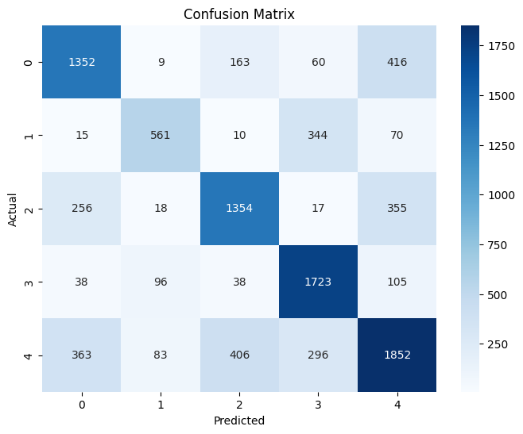

|  | Fold | Accuracy | Precision | Recall | F1-Score | Train Time (s) | Validation Time (s) |
| --- | --- | --- | --- | --- | --- | --- | --- |
| 0 | 1 | 0.660250 | 0.681986 | 0.644498 | 0.653027 | NaN | NaN |
| 1 | 2 | 0.646250 | 0.670159 | 0.659035 | 0.657748 | NaN | NaN |
| 2 | 3 | 0.607417 | 0.629366 | 0.587088 | 0.602091 | NaN | NaN |
| 3 | 4 | 0.611167 | 0.621594 | 0.596601 | 0.603512 | NaN | NaN |
| 4 | 5 | 0.621167 | 0.651751 | 0.615002 | 0.623277 | NaN | NaN |
| 5 | Total | 0.684200 | 0.690883 | 0.678567 | 0.680771 | 1.963562 | 0.018494 |

```python
from DecisionTreeTrainer import DecisionTreeTrainer

#To make the decisionTree shallow we can make max depth 10 and make minimum sample per barnch to 50 and we allow all features to be considered
decisionTreeBaseModel = DecisionTreeTrainer(model_type="single", result_path="./decisiontree/single", max_depth=10, min_samples_split=50, max_features=1)
#Initially checking with 6000 datapoints to estimate how much time will it take for training.
metrics_df = decisionTreeBaseModel.train(dataset_train_path, dataset_label_train_path, dataset_test_path, dataset_label_test_path, train_count=6000, test_count=1000)
display(metrics_df)
```

> Now checking with entire dataset of train and test

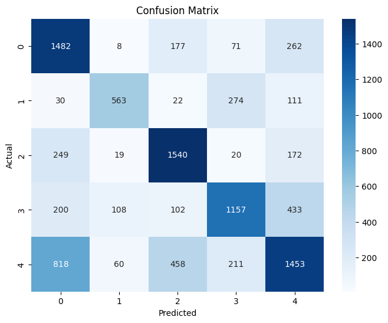

|  | Fold | Accuracy | Precision | Recall | F1-Score | Train Time (s) | Validation Time (s) |
| --- | --- | --- | --- | --- | --- | --- | --- |
| 0 | 1 | 0.669750 | 0.691093 | 0.660927 | 0.673131 | NaN | NaN |
| 1 | 2 | 0.622833 | 0.655685 | 0.611595 | 0.625365 | NaN | NaN |
| 2 | 3 | 0.679167 | 0.711999 | 0.651604 | 0.668768 | NaN | NaN |
| 3 | 4 | 0.665167 | 0.670015 | 0.661431 | 0.663091 | NaN | NaN |
| 4 | 5 | 0.688417 | 0.706835 | 0.697019 | 0.700598 | NaN | NaN |
| 5 | Total | 0.619500 | 0.642242 | 0.627367 | 0.626423 | 2.039226 | 0.020253 |

```python
from DecisionTreeTrainer import DecisionTreeTrainer

#To make the decisionTree shallow we can make max depth 10 and make minimum sample per barnch to 50 and we allow all features to be considered
decisionTreeBaseModel = DecisionTreeTrainer(model_type="single", result_path="./decisiontree/single", max_depth=10, min_samples_split=50, max_features=1)
#Note that we removed train count and test count
metrics_df = decisionTreeBaseModel.train(dataset_train_path, dataset_label_train_path, dataset_test_path, dataset_label_test_path)
display(metrics_df)
```

##### **Results - Simple Decision Tree**

- Decision tree max_feature = All, min_sample_split=50, max_depth=10
- Trained 60000 Test 10000
- We can see we achieved more than 60% in accuracy, recall, precision and f1
- Training time is 2 seconds

##### **Adjusting max_depth to 3X**

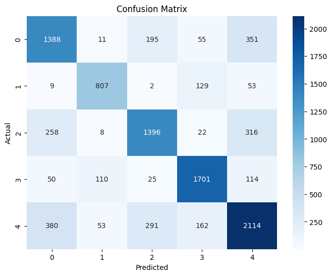

|  | Fold | Accuracy | Precision | Recall | F1-Score | Train Time (s) | Validation Time (s) |
| --- | --- | --- | --- | --- | --- | --- | --- |
| 0 | 1 | 0.740667 | 0.748411 | 0.744372 | 0.745879 | NaN | NaN |
| 1 | 2 | 0.740583 | 0.743572 | 0.742268 | 0.742882 | NaN | NaN |
| 2 | 3 | 0.719083 | 0.724626 | 0.722510 | 0.723420 | NaN | NaN |
| 3 | 4 | 0.748833 | 0.750905 | 0.743564 | 0.746930 | NaN | NaN |
| 4 | 5 | 0.755250 | 0.762808 | 0.758782 | 0.760700 | NaN | NaN |
| 5 | Total | 0.740600 | 0.750438 | 0.750833 | 0.750435 | 2.495144 | 0.024246 |

```python
from DecisionTreeTrainer import DecisionTreeTrainer

#changed max_depth tp 3x from earlier model
decisionTreeBaseModel = DecisionTreeTrainer(model_type="single", result_path="./decisiontree/single", max_depth=30, min_samples_split=50, max_features=1)
#Note that we removed train count and test count
metrics_df = decisionTreeBaseModel.train(dataset_train_path, dataset_label_train_path, dataset_test_path, dataset_label_test_path)
display(metrics_df)
```

- We achieved a really good improvement from ~65 percentage accuracy and other metrics to a ~75% accuracy with just 0.5 seconds of training time increment.
- This is a great result. Now before increasing further lets try with decreasing min_sample_split also.

##### **Adjust max_sample_split to half**

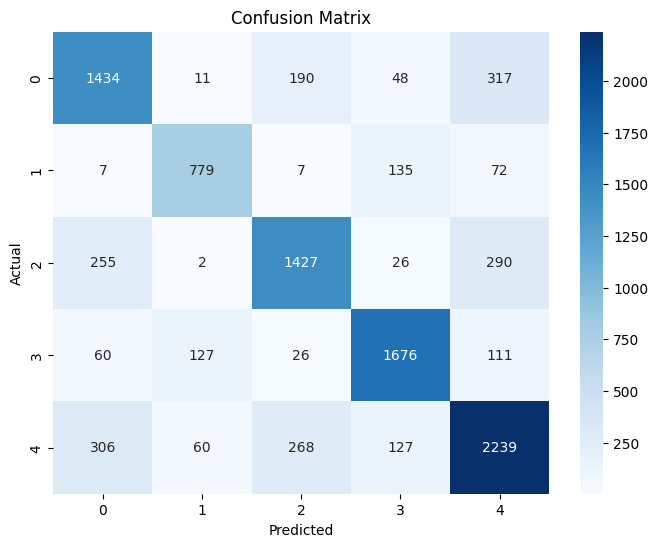

|  | Fold | Accuracy | Precision | Recall | F1-Score | Train Time (s) | Validation Time (s) |
| --- | --- | --- | --- | --- | --- | --- | --- |
| 0 | 1 | 0.749750 | 0.756527 | 0.750172 | 0.753116 | NaN | NaN |
| 1 | 2 | 0.761750 | 0.765755 | 0.765673 | 0.765609 | NaN | NaN |
| 2 | 3 | 0.734917 | 0.739230 | 0.739765 | 0.739145 | NaN | NaN |
| 3 | 4 | 0.761750 | 0.765043 | 0.764032 | 0.764509 | NaN | NaN |
| 4 | 5 | 0.750167 | 0.751813 | 0.753657 | 0.752687 | NaN | NaN |
| 5 | Total | 0.755500 | 0.761469 | 0.758767 | 0.759998 | 2.218822 | 0.02398 |

```python
from DecisionTreeTrainer import DecisionTreeTrainer

#changed max_depth tp 3x from earlier model | Keeping max_depth same and decreasing sample split size to half
decisionTreeBaseModel = DecisionTreeTrainer(model_type="single", result_path="./decisiontree/single", max_depth=30, min_samples_split=25, max_features=1)
#Note that we removed train count and test count
metrics_df = decisionTreeBaseModel.train(dataset_train_path, dataset_label_train_path, dataset_test_path, dataset_label_test_path)
display(metrics_df)
```

- We achieved a slight improvement. Though not significant.
- Training time reduced by 250 milliseconds. Again not a significant difference.
- We can try doubling the max_depth again.

##### **Max_depth to 60 from 30**

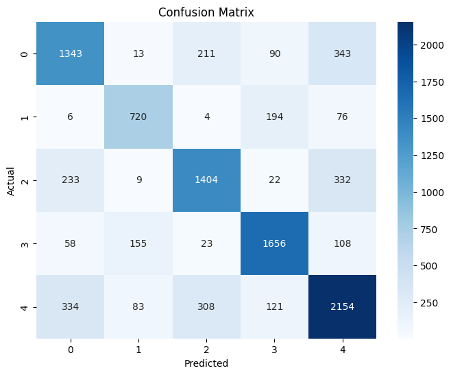

|  | Fold | Accuracy | Precision | Recall | F1-Score | Train Time (s) | Validation Time (s) |
| --- | --- | --- | --- | --- | --- | --- | --- |
| 0 | 1 | 0.750250 | 0.756851 | 0.753827 | 0.755202 | NaN | NaN |
| 1 | 2 | 0.744000 | 0.753439 | 0.750434 | 0.751874 | NaN | NaN |
| 2 | 3 | 0.757083 | 0.759450 | 0.760590 | 0.759831 | NaN | NaN |
| 3 | 4 | 0.753083 | 0.762818 | 0.757459 | 0.759914 | NaN | NaN |
| 4 | 5 | 0.743500 | 0.748546 | 0.745742 | 0.747101 | NaN | NaN |
| 5 | Total | 0.727700 | 0.728990 | 0.727900 | 0.728334 | 2.305419 | 0.021592 |

```python
from DecisionTreeTrainer import DecisionTreeTrainer

#changed max_depth tp 2x from previous model | Keeping min_sample_split back to 50
decisionTreeBaseModel = DecisionTreeTrainer(model_type="single", result_path="./decisiontree/single", max_depth=60, min_samples_split=50, max_features=1)
#Note that we removed train count and test count
metrics_df = decisionTreeBaseModel.train(dataset_train_path, dataset_label_train_path, dataset_test_path, dataset_label_test_path)
display(metrics_df)
```

We can see that the model is exhibiting worse results means we overfitted with 60 as max_depth. So the optimum value is somewhere between 30 and 60. Lets try 45 next

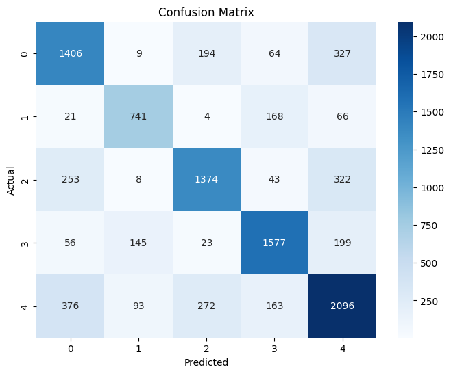

|  | Fold | Accuracy | Precision | Recall | F1-Score | Train Time (s) | Validation Time (s) |
| --- | --- | --- | --- | --- | --- | --- | --- |
| 0 | 1 | 0.746083 | 0.751884 | 0.751589 | 0.751730 | NaN | NaN |
| 1 | 2 | 0.747333 | 0.748069 | 0.744862 | 0.746346 | NaN | NaN |
| 2 | 3 | 0.742333 | 0.746974 | 0.745355 | 0.745856 | NaN | NaN |
| 3 | 4 | 0.753750 | 0.760797 | 0.753955 | 0.757180 | NaN | NaN |
| 4 | 5 | 0.748583 | 0.749916 | 0.749005 | 0.749453 | NaN | NaN |
| 5 | Total | 0.719400 | 0.724922 | 0.723633 | 0.724005 | 2.430513 | 0.021637 |

```python
from DecisionTreeTrainer import DecisionTreeTrainer

#changed max_depth tp middle of 30 and 60 from previous model | Keeping min_sample_split back to 50
decisionTreeBaseModel = DecisionTreeTrainer(model_type="single", result_path="./decisiontree/single", max_depth=45, min_samples_split=50, max_features=1)
#Note that we removed train count and test count
metrics_df = decisionTreeBaseModel.train(dataset_train_path, dataset_label_train_path, dataset_test_path, dataset_label_test_path)
display(metrics_df)
```

##### **Changing to 38**

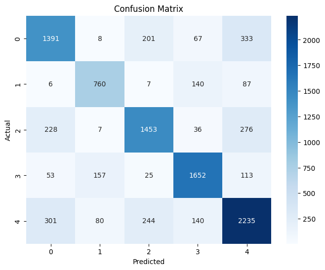

|  | Fold | Accuracy | Precision | Recall | F1-Score | Train Time (s) | Validation Time (s) |
| --- | --- | --- | --- | --- | --- | --- | --- |
| 0 | 1 | 0.738833 | 0.742574 | 0.737719 | 0.739894 | NaN | NaN |
| 1 | 2 | 0.740667 | 0.745447 | 0.744012 | 0.744716 | NaN | NaN |
| 2 | 3 | 0.748500 | 0.750326 | 0.745975 | 0.748029 | NaN | NaN |
| 3 | 4 | 0.758250 | 0.763830 | 0.762256 | 0.762994 | NaN | NaN |
| 4 | 5 | 0.744417 | 0.747528 | 0.744456 | 0.745848 | NaN | NaN |
| 5 | Total | 0.749100 | 0.750549 | 0.750600 | 0.750498 | 2.350938 | 0.021296 |

```python
from DecisionTreeTrainer import DecisionTreeTrainer

#we are kind of doing a binary search from 30 to 60 to find the optimum
decisionTreeBaseModel = DecisionTreeTrainer(model_type="single", result_path="./decisiontree/single", max_depth=38, min_samples_split=50, max_features=1)
#Note that we removed train count and test count
metrics_df = decisionTreeBaseModel.train(dataset_train_path, dataset_label_train_path, dataset_test_path, dataset_label_test_path)
display(metrics_df)
```

> We made an important mistake. It could be that the optimum is also between 10 and 30 and we saw an already overfit result from 30. So lets try 20.

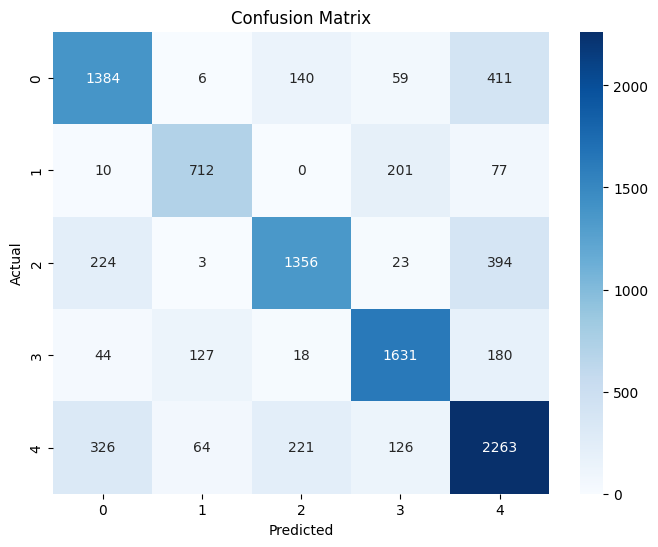

|  | Fold | Accuracy | Precision | Recall | F1-Score | Train Time (s) | Validation Time (s) |
| --- | --- | --- | --- | --- | --- | --- | --- |
| 0 | 1 | 0.733917 | 0.745843 | 0.734875 | 0.739875 | NaN | NaN |
| 1 | 2 | 0.725083 | 0.729531 | 0.719952 | 0.724029 | NaN | NaN |
| 2 | 3 | 0.719917 | 0.722449 | 0.721736 | 0.721848 | NaN | NaN |
| 3 | 4 | 0.736083 | 0.748132 | 0.733587 | 0.739553 | NaN | NaN |
| 4 | 5 | 0.735083 | 0.739545 | 0.733643 | 0.736311 | NaN | NaN |
| 5 | Total | 0.734600 | 0.747709 | 0.730367 | 0.737591 | 2.320285 | 0.020252 |

```python
from DecisionTreeTrainer import DecisionTreeTrainer

#we are kind of doing a binary search from 10 to 38 to find the optimum
decisionTreeBaseModel = DecisionTreeTrainer(model_type="single", result_path="./decisiontree/single", max_depth=20, min_samples_split=50, max_features=1)
#Note that we removed train count and test count
metrics_df = decisionTreeBaseModel.train(dataset_train_path, dataset_label_train_path, dataset_test_path, dataset_label_test_path)
display(metrics_df)
```

##### **Trying with 25**

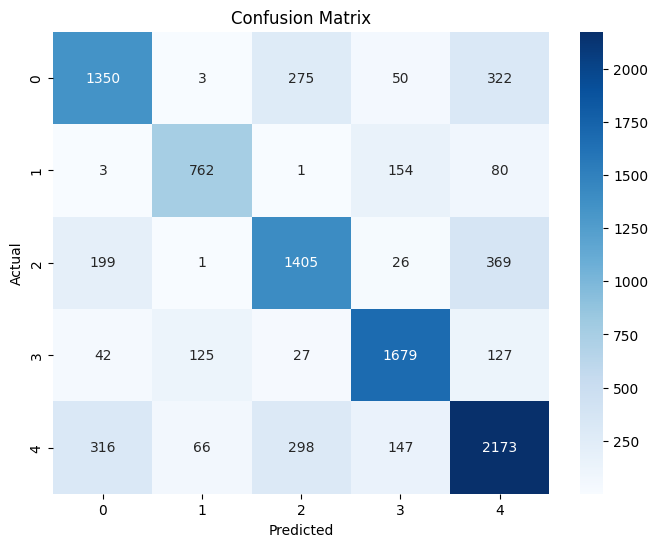

|  | Fold | Accuracy | Precision | Recall | F1-Score | Train Time (s) | Validation Time (s) |
| --- | --- | --- | --- | --- | --- | --- | --- |
| 0 | 1 | 0.73800 | 0.741761 | 0.743054 | 0.742215 | NaN | NaN |
| 1 | 2 | 0.77000 | 0.776332 | 0.769917 | 0.772760 | NaN | NaN |
| 2 | 3 | 0.75350 | 0.754131 | 0.755843 | 0.754846 | NaN | NaN |
| 3 | 4 | 0.74275 | 0.749519 | 0.744936 | 0.746954 | NaN | NaN |
| 4 | 5 | 0.74100 | 0.746624 | 0.742247 | 0.744271 | NaN | NaN |
| 5 | Total | 0.73690 | 0.745533 | 0.740667 | 0.742900 | 2.231392 | 0.021926 |

```python
from DecisionTreeTrainer import DecisionTreeTrainer

#we are kind of doing a binary search from 10 to 38 to find the optimum
decisionTreeBaseModel = DecisionTreeTrainer(model_type="single", result_path="./decisiontree/single", max_depth=25, min_samples_split=50, max_features=1)
#Note that we removed train count and test count
metrics_df = decisionTreeBaseModel.train(dataset_train_path, dataset_label_train_path, dataset_test_path, dataset_label_test_path)
display(metrics_df)
```

##### **Trying with 25**

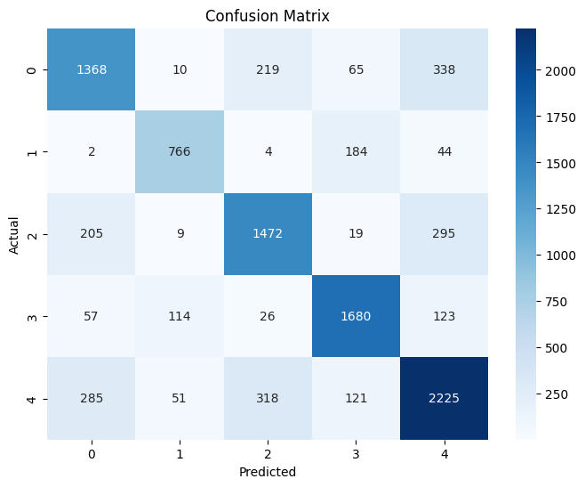

|  | Fold | Accuracy | Precision | Recall | F1-Score | Train Time (s) | Validation Time (s) |
| --- | --- | --- | --- | --- | --- | --- | --- |
| 0 | 1 | 0.745083 | 0.754533 | 0.748798 | 0.751409 | NaN | NaN |
| 1 | 2 | 0.752083 | 0.757302 | 0.755699 | 0.756418 | NaN | NaN |
| 2 | 3 | 0.737750 | 0.738504 | 0.741300 | 0.739758 | NaN | NaN |
| 3 | 4 | 0.735000 | 0.739499 | 0.736170 | 0.737711 | NaN | NaN |
| 4 | 5 | 0.734250 | 0.737100 | 0.737078 | 0.737041 | NaN | NaN |
| 5 | Total | 0.751100 | 0.757875 | 0.753533 | 0.755475 | 2.204076 | 0.021149 |

```python
from DecisionTreeTrainer import DecisionTreeTrainer

#we are kind of doing a binary search from 10 to 38 to find the optimum
decisionTreeBaseModel = DecisionTreeTrainer(model_type="single", result_path="./decisiontree/single", max_depth=25, min_samples_split=50, max_features=1)
#Note that we removed train count and test count
metrics_df = decisionTreeBaseModel.train(dataset_train_path, dataset_label_train_path, dataset_test_path, dataset_label_test_path)
display(metrics_df)
```

We can select 25 as the selected depth based on Occhams razor principle of keeping things simple if the gain is not substantial.

#### **Ensembling - Bagging**

- We are choosing max_depth as 25 min_split as 50 and we are not restricting the model about feature selection at each stage.
- Number of estimators we are keeping as 10 initially. We will experiment with more as we move forward.

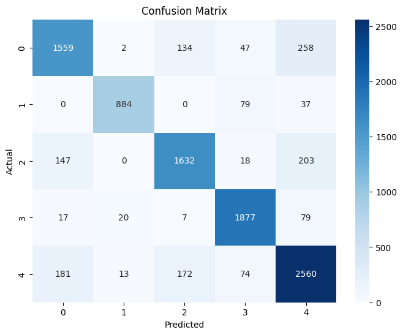

|  | Fold | Accuracy | Precision | Recall | F1-Score | Train Time (s) | Validation Time (s) |
| --- | --- | --- | --- | --- | --- | --- | --- |
| 0 | 1 | 0.850167 | 0.865573 | 0.851407 | 0.857705 | NaN | NaN |
| 1 | 2 | 0.856000 | 0.869220 | 0.853620 | 0.860502 | NaN | NaN |
| 2 | 3 | 0.858750 | 0.873969 | 0.859824 | 0.866266 | NaN | NaN |
| 3 | 4 | 0.860167 | 0.874506 | 0.859159 | 0.865936 | NaN | NaN |
| 4 | 5 | 0.857667 | 0.871291 | 0.856592 | 0.863016 | NaN | NaN |
| 5 | Total | 0.851200 | 0.866360 | 0.854267 | 0.859674 | 12.401815 | 0.397898 |

```python
from DecisionTreeTrainer import DecisionTreeTrainer

decisionTreeBaseModel = DecisionTreeTrainer(model_type="bagging", result_path="./decisiontree/ensemble-bagging", max_depth=25, min_samples_split=50, max_features=1, estimators=10)
#Note that we removed train count and test count
metrics_df = decisionTreeBaseModel.train(dataset_train_path, dataset_label_train_path, dataset_test_path, dataset_label_test_path)
display(metrics_df)
```

- We achieved really good improvement using ensembling based on bagging method.
- The achieved 10% improvement with 10 estimators only.
- The training time increased by ~6x-7x from simple decision tree with no ensembling.

##### **Increasing estimator size from 10 to 50**

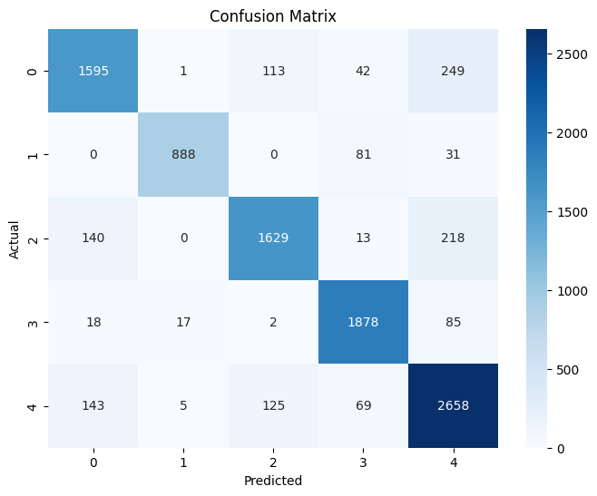

|  | Fold | Accuracy | Precision | Recall | F1-Score | Train Time (s) | Validation Time (s) |
| --- | --- | --- | --- | --- | --- | --- | --- |
| 0 | 1 | 0.870750 | 0.887787 | 0.872184 | 0.879078 | NaN | NaN |
| 1 | 2 | 0.874417 | 0.888875 | 0.874990 | 0.881252 | NaN | NaN |
| 2 | 3 | 0.871417 | 0.887188 | 0.872453 | 0.879061 | NaN | NaN |
| 3 | 4 | 0.876833 | 0.891956 | 0.875820 | 0.882833 | NaN | NaN |
| 4 | 5 | 0.869417 | 0.884302 | 0.867987 | 0.875024 | NaN | NaN |
| 5 | Total | 0.864800 | 0.881858 | 0.865000 | 0.872384 | 60.07472 | 2.038196 |

```python
from DecisionTreeTrainer import DecisionTreeTrainer

#Number of estimators to 50
decisionTreeBaseModel = DecisionTreeTrainer(model_type="bagging", result_path="./decisiontree/ensemble-bagging", max_depth=25, min_samples_split=50, max_features=1, estimators=50)
#Note that we removed train count and test count
metrics_df = decisionTreeBaseModel.train(dataset_train_path, dataset_label_train_path, dataset_test_path, dataset_label_test_path)
display(metrics_df)
```

We achived ~2% improvement with around 5x increase in training time. Now lets try with 100.

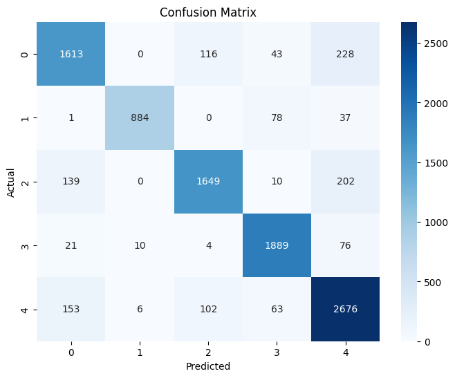

|  | Fold | Accuracy | Precision | Recall | F1-Score | Train Time (s) | Validation Time (s) |
| --- | --- | --- | --- | --- | --- | --- | --- |
| 0 | 1 | 0.867833 | 0.885407 | 0.868501 | 0.875974 | NaN | NaN |
| 1 | 2 | 0.873083 | 0.888403 | 0.872892 | 0.879821 | NaN | NaN |
| 2 | 3 | 0.868667 | 0.885531 | 0.869692 | 0.876709 | NaN | NaN |
| 3 | 4 | 0.873500 | 0.889079 | 0.871526 | 0.879094 | NaN | NaN |
| 4 | 5 | 0.869667 | 0.885072 | 0.869518 | 0.876301 | NaN | NaN |
| 5 | Total | 0.871100 | 0.887760 | 0.870300 | 0.877977 | 61.645122 | 2.195323 |

```python
from DecisionTreeTrainer import DecisionTreeTrainer

#Number of estimators to 100
decisionTreeBaseModel = DecisionTreeTrainer(model_type="bagging", result_path="./decisiontree/ensemble-bagging", max_depth=25, min_samples_split=50, max_features=1, estimators=50)
#Note that we removed train count and test count
metrics_df = decisionTreeBaseModel.train(dataset_train_path, dataset_label_train_path, dataset_test_path, dataset_label_test_path)
display(metrics_df)
```

##### **Trying with 30**

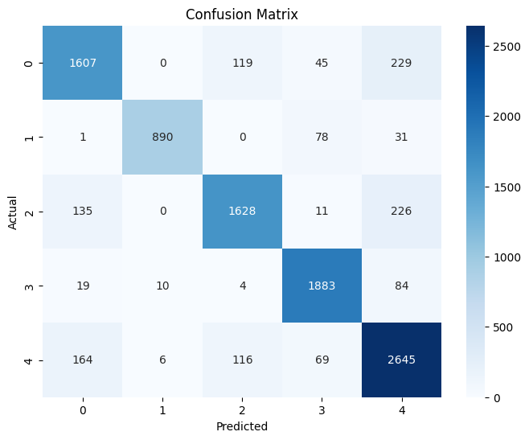

|  | Fold | Accuracy | Precision | Recall | F1-Score | Train Time (s) | Validation Time (s) |
| --- | --- | --- | --- | --- | --- | --- | --- |
| 0 | 1 | 0.863750 | 0.880192 | 0.865591 | 0.872071 | NaN | NaN |
| 1 | 2 | 0.874083 | 0.889930 | 0.872591 | 0.880227 | NaN | NaN |
| 2 | 3 | 0.863917 | 0.879868 | 0.864588 | 0.871306 | NaN | NaN |
| 3 | 4 | 0.868583 | 0.883311 | 0.867712 | 0.874538 | NaN | NaN |
| 4 | 5 | 0.867083 | 0.881587 | 0.865959 | 0.872805 | NaN | NaN |
| 5 | Total | 0.865300 | 0.882818 | 0.866133 | 0.873477 | 36.521802 | 1.346836 |

```python
from DecisionTreeTrainer import DecisionTreeTrainer

#Number of estimators to 30
decisionTreeBaseModel = DecisionTreeTrainer(model_type="bagging", result_path="./decisiontree/ensemble-bagging",
                                            max_depth=25, min_samples_split=50, max_features=1, estimators=30)
#Note that we removed train count and test count
metrics_df = decisionTreeBaseModel.train(dataset_train_path, dataset_label_train_path, dataset_test_path, dataset_label_test_path)
display(metrics_df)
```

#### **Trying with 20**

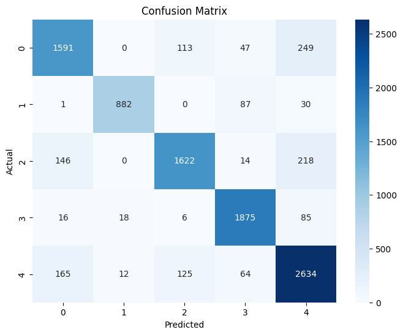

|  | Fold | Accuracy | Precision | Recall | F1-Score | Train Time (s) | Validation Time (s) |
| --- | --- | --- | --- | --- | --- | --- | --- |
| 0 | 1 | 0.863333 | 0.880416 | 0.864980 | 0.871802 | NaN | NaN |
| 1 | 2 | 0.872000 | 0.885880 | 0.871277 | 0.877765 | NaN | NaN |
| 2 | 3 | 0.863750 | 0.880085 | 0.864928 | 0.871705 | NaN | NaN |
| 3 | 4 | 0.864917 | 0.880184 | 0.864636 | 0.871482 | NaN | NaN |
| 4 | 5 | 0.864417 | 0.879236 | 0.863627 | 0.870423 | NaN | NaN |
| 5 | Total | 0.860400 | 0.876574 | 0.860800 | 0.867736 | 25.153277 | 0.909436 |

```python
from DecisionTreeTrainer import DecisionTreeTrainer

#Number of estimators to 20
decisionTreeBaseModel = DecisionTreeTrainer(model_type="bagging", result_path="./decisiontree/ensemble-bagging",
                                            max_depth=25, min_samples_split=50, max_features=1, estimators=20)
#Note that we removed train count and test count
metrics_df = decisionTreeBaseModel.train(dataset_train_path, dataset_label_train_path, dataset_test_path, dataset_label_test_path)
display(metrics_df)
```

##### **Trying with 15**

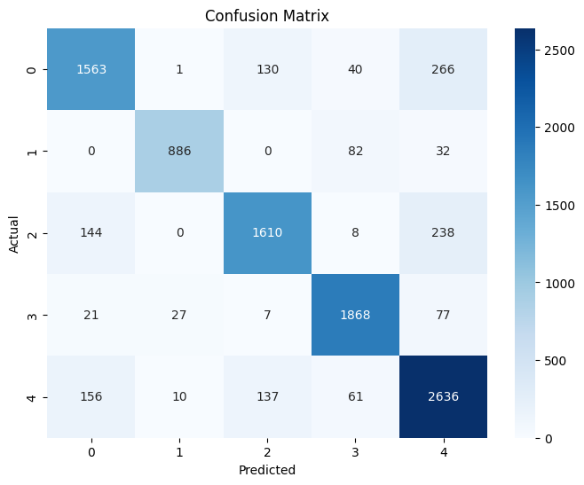

|  | Fold | Accuracy | Precision | Recall | F1-Score | Train Time (s) | Validation Time (s) |
| --- | --- | --- | --- | --- | --- | --- | --- |
| 0 | 1 | 0.859833 | 0.876758 | 0.862219 | 0.868714 | NaN | NaN |
| 1 | 2 | 0.865333 | 0.878995 | 0.864547 | 0.871085 | NaN | NaN |
| 2 | 3 | 0.860250 | 0.874604 | 0.861112 | 0.867237 | NaN | NaN |
| 3 | 4 | 0.863917 | 0.878604 | 0.862641 | 0.869478 | NaN | NaN |
| 4 | 5 | 0.861000 | 0.874542 | 0.860174 | 0.866514 | NaN | NaN |
| 5 | Total | 0.856300 | 0.872324 | 0.857033 | 0.863792 | 18.961133 | 0.622188 |

```python
from DecisionTreeTrainer import DecisionTreeTrainer

#Number of estimators to 15
decisionTreeBaseModel = DecisionTreeTrainer(model_type="bagging", result_path="./decisiontree/ensemble-bagging",
                                            max_depth=25, min_samples_split=50, max_features=1, estimators=15)
#Note that we removed train count and test count
metrics_df = decisionTreeBaseModel.train(dataset_train_path, dataset_label_train_path, dataset_test_path, dataset_label_test_path)
display(metrics_df)
```

- After trying multiple estimators an optimum value will be 20 estimators.
- With 20 we achieve a gain of 10% ie from ~75% in simple model to ~86% with ensemble bagging and 20 estimators.

#### **Ensemble - Boosting**

- We will use the optimum numbers we arrived at from the previous iterations for boosting method to get started.

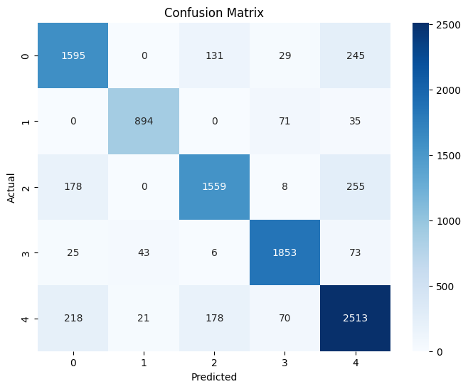

|  | Fold | Accuracy | Precision | Recall | F1-Score | Train Time (s) | Validation Time (s) |
| --- | --- | --- | --- | --- | --- | --- | --- |
| 0 | 1 | 0.840083 | 0.854748 | 0.843301 | 0.848471 | NaN | NaN |
| 1 | 2 | 0.845333 | 0.858351 | 0.849163 | 0.853231 | NaN | NaN |
| 2 | 3 | 0.842917 | 0.855005 | 0.846271 | 0.850135 | NaN | NaN |
| 3 | 4 | 0.843000 | 0.855438 | 0.845750 | 0.849964 | NaN | NaN |
| 4 | 5 | 0.833917 | 0.845413 | 0.836234 | 0.840444 | NaN | NaN |
| 5 | Total | 0.841400 | 0.854765 | 0.847033 | 0.850567 | 32.447685 | 0.451083 |

```python
from DecisionTreeTrainer import DecisionTreeTrainer

#Number of estimators to 20
decisionTreeBaseModel = DecisionTreeTrainer(model_type="boosting", result_path="./decisiontree/ensemble-boosting", max_depth=25, min_samples_split=50, max_features=1, estimators=20)
#Note that we removed train count and test count
metrics_df = decisionTreeBaseModel.train(dataset_train_path, dataset_label_train_path, dataset_test_path, dataset_label_test_path)
display(metrics_df)
```

##### **Trying with default values for all decision tree parameters and letting the ensemble model use an optimum value on its own on bagging method**

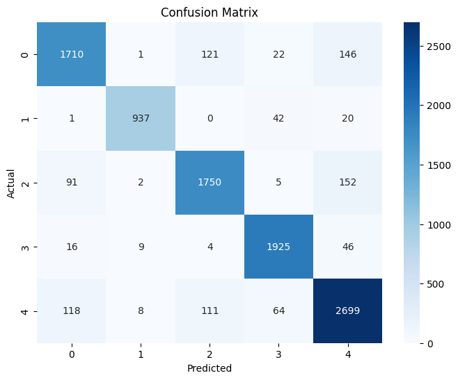

|  | Fold | Accuracy | Precision | Recall | F1-Score | Train Time (s) | Validation Time (s) |
| --- | --- | --- | --- | --- | --- | --- | --- |
| 0 | 1 | 0.898917 | 0.908390 | 0.900854 | 0.904365 | NaN | NaN |
| 1 | 2 | 0.908417 | 0.915766 | 0.910162 | 0.912824 | NaN | NaN |
| 2 | 3 | 0.899250 | 0.906977 | 0.901921 | 0.904307 | NaN | NaN |
| 3 | 4 | 0.901333 | 0.909070 | 0.902278 | 0.905433 | NaN | NaN |
| 4 | 5 | 0.903917 | 0.910501 | 0.905354 | 0.907772 | NaN | NaN |
| 5 | Total | 0.902100 | 0.912014 | 0.905833 | 0.908725 | 7305.551802 | 1.951933 |

```python
from DecisionTreeTrainer import DecisionTreeTrainer

#Number of estimators to 100
decisionTreeBaseModel = DecisionTreeTrainer(model_type="bagging", result_path="./decisiontree/ensemble-bagging")
#Note that we removed train count and test count
metrics_df = decisionTreeBaseModel.train(dataset_train_path, dataset_label_train_path, dataset_test_path, dataset_label_test_path)
display(metrics_df)
```

> This points to the fact how important the hyperparameters are while training. The tradeoff is between time and accuracy.

### **Part-B Guessing the mystery label**

#### **Multi Layer Perceptron**

```python
dataset_train_path = "../dataset/fashionmnist-datafiles/x_train.csv"
dataset_test_path = "../dataset/fashionmnist-datafiles/x_test.csv"
dataset_label_train_path = "../dataset/fashionmnist-datafiles/y_train.csv"
dataset_label_test_path = "../dataset/fashionmnist-datafiles/y_test.csv"
```

```python
import numpy as np
from sklearn.model_selection import train_test_split
from sklearn.neural_network import MLPClassifier
from sklearn.datasets import load_iris
from sklearn.metrics import accuracy_score
import seaborn as sns
import pandas as pd
import matplotlib.pyplot as plt
from sklearn.metrics import confusion_matrix
from datetime import datetime
import os
from scipy.stats import zscore


def train_and_return_mlp(iter=10, result_path="./mlp"):
    formatted_time = datetime.now().strftime("%m-%d-%H-%M")
    name = f"mlp-{iter}-{formatted_time}"
    result_folder = os.path.join(result_path, name)
    os.makedirs(result_folder, exist_ok=True)
    x_train = np.array(pd.read_csv(dataset_train_path).values)
    y_train = np.array(pd.read_csv(dataset_label_train_path).values.flatten())
    x_test = np.array(pd.read_csv(dataset_test_path).values)
    y_test = np.array(pd.read_csv(dataset_label_test_path).values.flatten())

    x_train = zscore(x_train, axis=0)
    x_test = zscore(x_test, axis=0)

    # Create a neural network with 3 hidden layers
    # First hidden layer: 256 neurons, second hidden layer: 128 neurons, third hidden layer: 64 neurons
    model = MLPClassifier(hidden_layer_sizes=(256, 128, 64), max_iter=iter, random_state=42)

    # Train the model on the training data
    start_time = datetime.now()
    model.fit(x_train, y_train)
    total_training_time = datetime.now() - start_time

    # Predict on the test set
    y_pred = model.predict(x_test)

    # Evaluate the model
    accuracy = accuracy_score(y_test, y_pred)
    print(f'Accuracy: {accuracy * 100:.2f}%')

    cm = confusion_matrix(y_test, y_pred)
    sns.heatmap(cm, annot=True, fmt='d', cmap='Blues', xticklabels=np.unique(y_test), yticklabels=np.unique(y_test))
    # Add titles and labels
    plt.title("Confusion Matrix")
    plt.xlabel("Predicted")
    plt.ylabel("Actual")
    plt.savefig(os.path.join(result_folder, "confusion_matrix.png"))
    # Show the plot
    plt.show()

    cm = confusion_matrix(y_test, y_pred)
    num_classes = cm.shape[0]
    accuracy = []
    precision = []
    recall = []
    f1_score = []
    # Calculate metrics for each class
    for i in range(num_classes):
        TP = cm[i, i]  # True positive
        FP = cm[:, i].sum() - TP  # False positive
        FN = cm[i, :].sum() - TP  # False negative
        TN = cm.sum() - (TP + FP + FN)  # True negative

        # Accuracy is the overall proportion of correct predictions
        acc = (TP + TN) / cm.sum()

        # Precision: TP / (TP + FP)
        if (TP + FP) == 0:
            prec = 0
        else:
            prec = TP / (TP + FP)

        # Recall: TP / (TP + FN)
        if (TP + FN) == 0:
            rec = 0
        else:
            rec = TP / (TP + FN)

        # F1-Score: 2 * (Precision * Recall) / (Precision + Recall)
        if (prec + rec) == 0:
            f1 = 0
        else:
            f1 = 2 * (prec * rec) / (prec + rec)

        # Append the metrics to the lists
        accuracy.append(acc)
        precision.append(prec)
        recall.append(rec)
        f1_score.append(f1)

    # Create a DataFrame to display the metrics for each class
    metrics_df = pd.DataFrame({
        'Class': np.arange(num_classes),
        'Accuracy': accuracy,
        'Precision': precision,
        'Recall': recall,
        'F1-Score': f1_score,
        'Total Training Time': total_training_time
    })
    metrics_csv_path = os.path.join(result_folder, "metrics.csv")
    metrics_df.to_csv(metrics_csv_path, index=False)
    return model, metrics_df
```

#### **Iterations 10 | Hidden layers : 3 | 256, 128, 64**

```
Accuracy: 91.16%
```

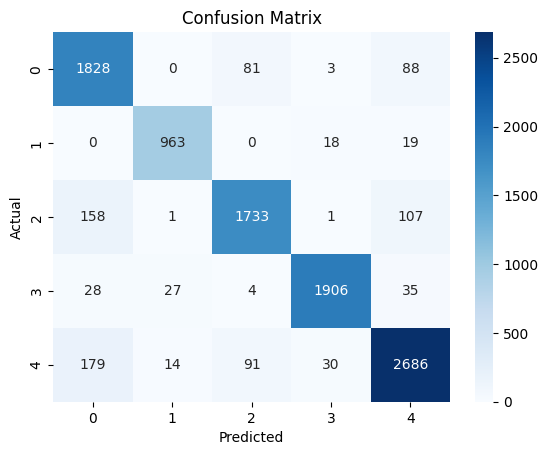

|  | Class | Accuracy | Precision | Recall | F1-Score | Total Training Time |
| --- | --- | --- | --- | --- | --- | --- |
| 0 | 0 | 0.9463 | 0.833561 | 0.914000 | 0.871929 | 0 days 00:01:10.605556 |
| 1 | 1 | 0.9921 | 0.958209 | 0.963000 | 0.960599 | 0 days 00:01:10.605556 |
| 2 | 2 | 0.9557 | 0.907805 | 0.866500 | 0.886672 | 0 days 00:01:10.605556 |
| 3 | 3 | 0.9854 | 0.973442 | 0.953000 | 0.963113 | 0 days 00:01:10.605556 |
| 4 | 4 | 0.9437 | 0.915162 | 0.895333 | 0.905139 | 0 days 00:01:10.605556 |

```python
trained_model, results_df = train_and_return_mlp(10)
display(results_df)
```

- With just 10 iterations with multi layer perceptron we reached ~91% accuracy overall
- When compared with ensemble techniques this is a visible improvement.
- We can try with more iterations.
- Took around 70 seconds for training

```
Accuracy: 92.28%
```

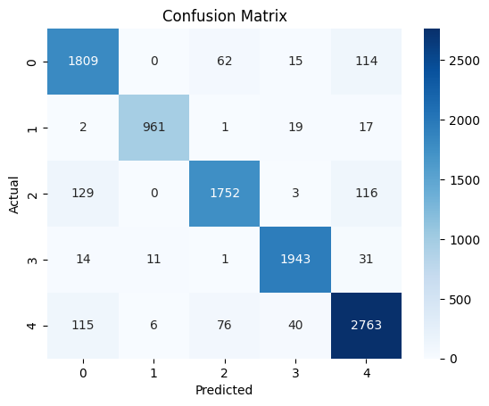

|  | Class | Accuracy | Precision | Recall | F1-Score | Total Training Time |
| --- | --- | --- | --- | --- | --- | --- |
| 0 | 0 | 0.9549 | 0.874335 | 0.9045 | 0.889162 | 0 days 00:04:40.771299 |
| 1 | 1 | 0.9944 | 0.982618 | 0.9610 | 0.971689 | 0 days 00:04:40.771299 |
| 2 | 2 | 0.9612 | 0.926004 | 0.8760 | 0.900308 | 0 days 00:04:40.771299 |
| 3 | 3 | 0.9866 | 0.961881 | 0.9715 | 0.966667 | 0 days 00:04:40.771299 |
| 4 | 4 | 0.9485 | 0.908583 | 0.9210 | 0.914749 | 0 days 00:04:40.771299 |

```python
trained_model, results_df = train_and_return_mlp(50)
display(results_df)
```

#### **Generate Embeddings from last layer**

- We will be using the last trained model trained with 92% accuracy with 50 iterations.
- Also note that classes 1 and 3 has very high accuracy almost close to perfection. This will be helpful when we try to dig the mystery label.

```python
def get_hidden_layer_activations(model, X, layer_index):
    """Calculate the activations of a specified hidden layer.

    Parameters:
    - model: Trained instance of sklearn.neural_network.MLPClassifier.
    - X: Input data, numpy array of shape (n_samples, n_features).
    - layer_index: Index of the hidden layer for which to compute activations.

    Returns:
    - Activations of the specified hidden layer, numpy array of shape (n_samples, n_units_in_layer).
    """
    if layer_index < 0 or layer_index >= len(model.coefs_) - 1:
        raise ValueError("Invalid layer_index.")

    # Forward propagate through the network until the specified layer
    activations = X
    for i in range(layer_index + 1):
        activations = np.dot(activations, model.coefs_[i]) + model.intercepts_[i]
        if i < len(model.coefs_) - 1:
            activations = np.maximum(0, activations)

    return activations

mlp = trained_model
i = len(mlp.hidden_layer_sizes)-1
data = np.array(pd.read_csv(dataset_test_path).values)
# Retrieve activations for the ith hidden layer
embeddings = get_hidden_layer_activations(mlp, data, i)
display(embeddings.shape)
```

```
(10000, 64)
```

- We generated embeddings for all the 10000 test images. The features are now captured or squashed into 64 by the MLP.
- Now we can further use PCA to capture variance and further reduce the features.

```python
import numpy as np
import matplotlib.pyplot as plt
from sklearn.decomposition import PCA
from sklearn.discriminant_analysis import LinearDiscriminantAnalysis as LDA
from matplotlib.cm import ScalarMappable


def perform_pca_lda(embeddings, labels):
    pca = PCA(n_components=2)
    X_pca = pca.fit_transform(embeddings, labels)

    # 2. Perform LDA
    lda = LDA(n_components=2)
    X_lda = lda.fit_transform(embeddings, labels)

    # Define a colormap
    colormap = plt.cm.tab10
    norm = plt.Normalize(vmin=min(labels), vmax=max(labels))
    sm = ScalarMappable(cmap=colormap, norm=norm)
    sm.set_array([])

    # 3. Plotting the results
    plt.figure(figsize=(12, 6))

    # PCA Plot
    plt.subplot(1, 2, 1)
    sns.scatterplot(x=X_pca[:, 0], y=X_pca[:, 1], hue=labels, palette="tab10", s=20, alpha=0.7)
    #scatter = plt.scatter(X_pca[:, 0], X_pca[:, 1], c=labels, cmap='viridis', s=10, alpha=0.7)
    plt.title("PCA - 2 Components")
    plt.xlabel("PCA Component 1")
    plt.ylabel("PCA Component 2")
    plt.colorbar(sm, label="Class")
    plt.legend(title="Class")


    # LDA Plot
    plt.subplot(1, 2, 2)
    sns.scatterplot(x=X_lda[:, 0], y=X_lda[:, 1], hue=labels, palette="tab10", s=20, alpha=0.7)
    #scatter = plt.scatter(X_lda[:, 0], X_lda[:, 1], c=labels, cmap='viridis', s=10, alpha=0.7)
    plt.title("LDA - 2 Components")
    plt.xlabel("LDA Component 1")
    plt.ylabel("LDA Component 2")
    plt.colorbar(sm, label="Class")
    plt.legend(title="Class")

    plt.tight_layout()
    plt.show()
```

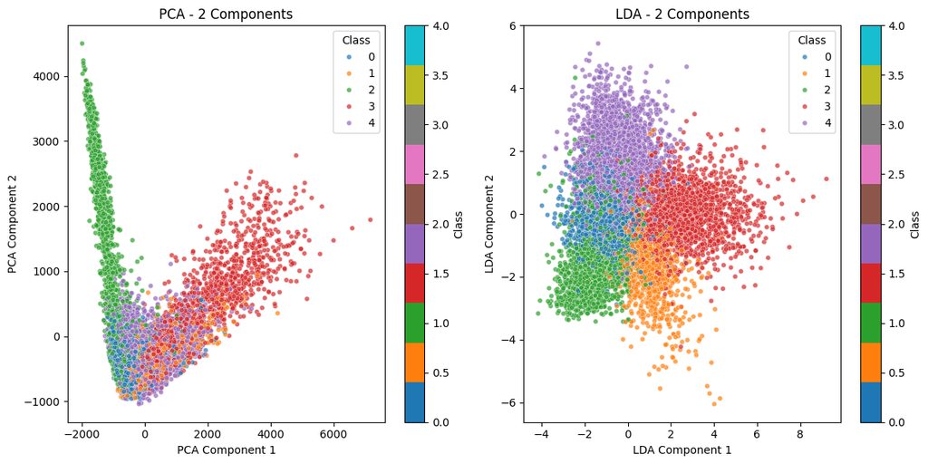

```python
y_test = np.array(pd.read_csv(dataset_label_test_path).values.flatten())
perform_pca_lda(embeddings, y_test)
```

- We didnt normalize the test datasets before passing through the model for generating embeddings.
- Lets do one more plot with zscore applied to the test like we did while training.

```python
mlp = trained_model
i = len(mlp.hidden_layer_sizes)-1
data = zscore(np.array(pd.read_csv(dataset_test_path).values), axis=0)
# Retrieve activations for the ith hidden layer
embeddings = get_hidden_layer_activations(mlp, data, i)
display(embeddings.shape)
```

```
(10000, 64)
```

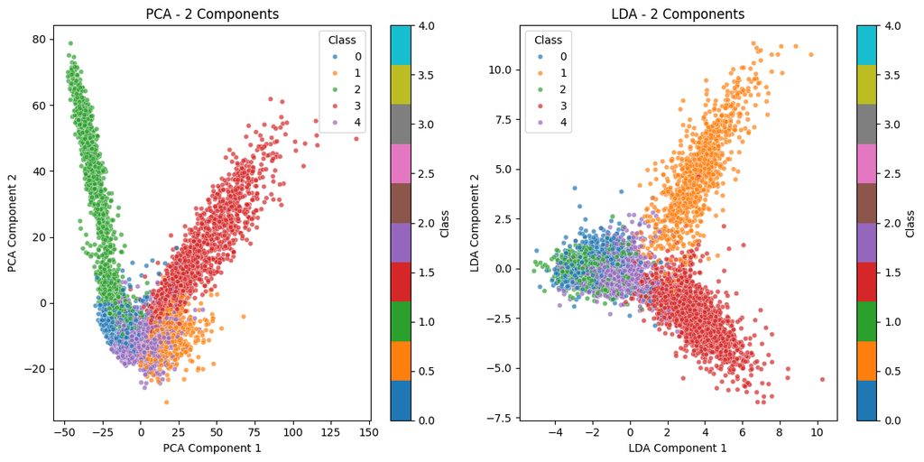

```python
y_test = np.array(pd.read_csv(dataset_label_test_path).values.flatten())
perform_pca_lda(embeddings, y_test)
```

- What we can infer from the PCA
- Class 2 will have PCA1 less than 0 and PCA2 greater than 0
- If PCA2 is greater than 0 and PCA1 is greater than 1 its ighly likely that the class is 3
- What we can infer from the LDA
- If LDA1 is greater than 2 and LDA2 is greater than 2 its highly likely its class 1
- If LDA1 is greater than 2 and LDA2 is less than 0 its highly likely that it represents class 3

Using this info also we can try dig out the images for atleast 3 classes and see it there is a pattern. We will do that in the end.

#### **Perform K-Means Clustering**

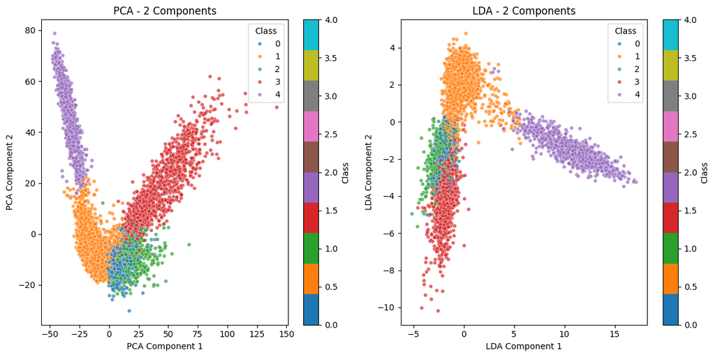

```python
from sklearn.cluster import KMeans

kmeans = KMeans(n_clusters=5, random_state=0)
kmeans.fit(embeddings)
labels_from_kmeans = kmeans.labels_
#note that inctead of using the y_test labels we are now using the labels generated by the kmeans clustering
perform_pca_lda(embeddings, labels_from_kmeans)
```

- We can see that the PCA graph is almost matching with that generated with the help of actual labels.
- To uncover the mystery label we can use PCA plot of both the labels.

LDA component plot has a V shape in both but the alignment has changed. I am unable to find a reasoning for this. I understand that the labels can be assigned differently but why the plot is changing placement while maintaining relative distribution is something I have to find out.

#### **Trying to identify the classes**

```python
x_train = np.array(pd.read_csv(dataset_train_path).values)
y_train = np.array(pd.read_csv(dataset_label_train_path).values.flatten())
x_test = np.array(pd.read_csv(dataset_test_path).values)
y_test = np.array(pd.read_csv(dataset_label_test_path).values.flatten())

unique_counts = pd.DataFrame(np.unique(labels_from_kmeans, return_counts=True)).T
unique_counts.columns = ['KMeans', 'Count']
unique_counts_actual = pd.DataFrame(np.unique(y_train, return_counts=True)).T
unique_counts_actual.columns = ['Actual', 'Count']
display(unique_counts_actual.sort_values(by='Count', ascending=False))
display(unique_counts.sort_values(by='Count', ascending=False))
```

|  | Actual | Count |
| --- | --- | --- |
| 4 | 4 | 18000 |
| 0 | 0 | 12000 |
| 2 | 2 | 12000 |
| 3 | 3 | 12000 |
| 1 | 1 | 6000 |

|  | KMeans | Count |
| --- | --- | --- |
| 1 | 1 | 5375 |
| 3 | 3 | 1693 |
| 0 | 0 | 1142 |
| 2 | 2 | 920 |
| 4 | 4 | 870 |

```python
import matplotlib.pyplot as plt
import os
import random




def plot_image(x_test, y_test, n=10):
    unique_labels = set(y_test)  # Get unique labels from y_test
    plt.figure(figsize=(15, len(unique_labels) * 3))  # Adjust the figure size based on the number of unique labels

    # Loop through each unique label
    for i, label in enumerate(unique_labels):
        # Find the indices of all images with the current label
        label_indices = [idx for idx, val in enumerate(y_test) if val == label]

        # Randomly select n images (or fewer if there aren't enough)
        selected_indices = random.sample(label_indices, min(n, len(label_indices)))

        # Loop to plot n randomly selected images per label
        for j, idx in enumerate(selected_indices):
            plt.subplot(len(unique_labels), n, i * n + j + 1)  # n images per row
            plt.imshow(x_test[idx].reshape(28, 28), cmap="gray")
            plt.title(f"Label: {y_test[idx]}")
            plt.axis("off")

    plt.tight_layout()
    plt.show()
```

#### **Printing images with labels created by kmeans Clustering**

[figure not shown]

```python
#note that we are using the labels created from clustering and not the actual labels
plot_image(x_test=x_test, y_test=labels_from_kmeans, n=10)
```

##### **Match the Class labels from actual labels and cluster labels using PCA plot**

```python
def perform_pca_on_both(embeddings, actualLabel, clusterLabel):
    pca = PCA(n_components=2)
    X_pca = pca.fit_transform(embeddings, actualLabel)

    # 2. Perform LDA
    pca2 = PCA(n_components=2)
    X_pca2 = pca.fit_transform(embeddings, clusterLabel)

    # Define a colormap
    colormap = plt.cm.tab10
    norm = plt.Normalize(vmin=min(actualLabel), vmax=max(actualLabel))
    sm = ScalarMappable(cmap=colormap, norm=norm)
    sm.set_array([])

    # Define a colormap
    colormap2 = plt.cm.tab10
    norm2 = plt.Normalize(vmin=min(clusterLabel), vmax=max(clusterLabel))
    sm2 = ScalarMappable(cmap=colormap2, norm=norm2)
    sm2.set_array([])

    # 3. Plotting the results
    plt.figure(figsize=(12, 6))

    # PCA Plot
    plt.subplot(1, 2, 1)
    sns.scatterplot(x=X_pca[:, 0], y=X_pca[:, 1], hue=actualLabel, palette="tab10", s=20, alpha=0.7)
    #scatter = plt.scatter(X_pca[:, 0], X_pca[:, 1], c=labels, cmap='viridis', s=10, alpha=0.7)
    plt.title("PCA - Actual Labels")
    plt.xlabel("PCA Component 1")
    plt.ylabel("PCA Component 2")
    plt.colorbar(sm, label="Class")
    plt.legend(title="Class")


    # LDA Plot
    plt.subplot(1, 2, 2)
    sns.scatterplot(x=X_pca2[:, 0], y=X_pca2[:, 1], hue=clusterLabel, palette="tab10", s=20, alpha=0.7)
    #scatter = plt.scatter(X_lda[:, 0], X_lda[:, 1], c=labels, cmap='viridis', s=10, alpha=0.7)
    plt.title("PCA Cluster Labels")
    plt.xlabel("PCA Component 1")
    plt.ylabel("PCA Component 2")
    plt.colorbar(sm2, label="Class")
    plt.legend(title="Class")

    plt.tight_layout()
    plt.show()
```

[figure not shown]

```python
perform_pca_on_both(embeddings, y_test, labels_from_kmeans)
```

```python
df = pd.DataFrame({
    "Actual Label": [2, 3, 0, 4, 1],  # List of actual labels
    "Cluster Label": [4, 3, 1, 0, 2]  # Corresponding cluster labels
})
display(df)
```

|  | Actual Label | Cluster Label |
| --- | --- | --- |
| 0 | 2 | 4 |
| 1 | 3 | 3 |
| 2 | 0 | 1 |
| 3 | 4 | 0 |
| 4 | 1 | 2 |

#### **----------------------------------------------------------------------------------------------------------------------------------------**

#### **Some Doubts**

- I actually plotted some train and test images also and saw that there were some mixed images in classes.
- Saw that the clustering was giving better results than the actual test images. ( like in label 2 I can see both topwear and bottomwear when printing using the actual labels)
- So I am confused about the reason behind this.
- And if this is indeed the correct reasoning, does the better clustering using kmeans mean that the MLP was actually generating the embedding correctly. ie in reality the error rate that the perceptron showed was in fact because it was classifying correctly and the given test labelling had some wrong labels ?

Example is given below

[figure not shown]

```python
#note that the label used is ytest and not the labels generated from kmeans.
plot_image(x_test=x_test, y_test=y_test, n=10)
```